# Analysis of General Melting Point Prediction Data

Hank Magan

09/14/2021

Abstract

The following report analyzes data given from a paper titled *General Melting Point PRediction Based on a Diverse Compound Data Set and Artificial Neural Networks*, researched by M. Karthikeyan. The dataset contains mulitple properties of a variety of compounds, with an ultimate focus on melting point. The paper uses these properties (referred to as descriptors) to derive a general model for predicting melting point. As will be discussed in this report, these descriptors can be further explored for one’s own purposes using a variety of statistical models, and can be compared against the predicted melting points as given by Karthikeyan.

## Examining Basic Structure and Descriptive Statistics

When presented with unseen data, it is wise to examine it before doing any modeling. This will provide a general overview of how the data is structured, the size of the dataset, descriptive statistics, and sample data from the first few and last few rows. This is an instrumental process in understanding exactly how data should be manipulated as it is explored further.

```r
# check structure
str(mp)
```

```
## 'data.frame':    4450 obs. of  18 variables:
##  $ ï..structure : chr  "O=C1Cc2ccccc21" "Clc1ccc(cc1)C1c2c(OC(N)=C1C#N)[nH][nH0]c2C(F)(F)F" "O=C(OC)C(=Cc1ccccc1)Cc1ccccc1" "FC(F)(F)c1[nH0]cc2ccccc2c1" ...
##  $ mp           : num  14 20.5 27.5 30.5 31 31.5 32 32.5 33 34 ...
##  $ rings        : int  6 11 12 10 6 6 6 5 12 12 ...
##  $ heavy.atoms  : int  9 23 19 14 12 14 12 10 16 14 ...
##  $ single.bonds : int  9 20 22 10 16 19 14 12 21 16 ...
##  $ triple.bonds : int  0 1 0 0 0 0 0 0 0 0 ...
##  $ reactive     : int  0 0 0 0 1 0 0 0 0 0 ...
##  $ molar.mass   : num  118 341 252 197 162 ...
##  $ refractivity : num  3.56 7.73 7.8 4.73 4.65 ...
##  $ formal.charge: int  0 0 0 0 0 0 0 0 0 0 ...
##  $ logP         : num  1.43 3.64 3.49 3.57 1.94 ...
##  $ tpsa         : num  17.1 87.7 26.3 12.9 26.3 ...
##  $ dipole.moment: num  2.72 6.32 1.91 5.2 1.76 ...
##  $ energy       : num  -57.8 -189.1 -123.5 -119.7 -83.5 ...
##  $ density      : num  0.959 1.296 0.946 1.195 0.978 ...
##  $ volume       : num  123 263 267 165 166 ...
##  $ PCA1         : num  15.55 1.92 2.98 11.03 10.97 ...
##  $ PCA2         : num  1.622 0.502 2.723 1.826 -0.905 ...
```

```r
# check descriptive stats
summary(mp)
```

```
##  ï..structure             mp            rings         heavy.atoms
##  Length:4450        Min.   : 14.0   Min.   : 0.000   Min.   : 6.00
##  Class :character   1st Qu.:117.5   1st Qu.: 6.000   1st Qu.:17.00
##  Mode  :character   Median :161.5   Median :11.000   Median :22.00
##                     Mean   :165.3   Mean   : 9.956   Mean   :22.24
##                     3rd Qu.:209.4   3rd Qu.:12.000   3rd Qu.:26.00
##                     Max.   :392.5   Max.   :36.000   Max.   :59.00
##
##   single.bonds     triple.bonds       reactive        molar.mass
##  Min.   :  4.00   Min.   :0.0000   Min.   :0.0000   Min.   : 84.08
##  1st Qu.: 19.00   1st Qu.:0.0000   1st Qu.:0.0000   1st Qu.:243.27
##  Median : 24.00   Median :0.0000   Median :0.0000   Median :308.33
##  Mean   : 28.24   Mean   :0.1058   Mean   :0.2209   Mean   :317.41
##  3rd Qu.: 33.00   3rd Qu.:0.0000   3rd Qu.:0.0000   3rd Qu.:375.38
##  Max.   :119.00   Max.   :4.0000   Max.   :1.0000   Max.   :815.62
##
##   refractivity    formal.charge           logP             tpsa
##  Min.   : 1.992   Min.   :-3.00000   Min.   :-6.023   Min.   :  0.00
##  1st Qu.: 6.609   1st Qu.: 0.00000   1st Qu.: 2.106   1st Qu.: 38.33
##  Median : 8.310   Median : 0.00000   Median : 3.221   Median : 61.07
##  Mean   : 8.514   Mean   : 0.01236   Mean   : 3.337   Mean   : 67.50
##  3rd Qu.:10.179   3rd Qu.: 0.00000   3rd Qu.: 4.529   3rd Qu.: 88.06
##  Max.   :19.354   Max.   : 2.00000   Max.   :12.780   Max.   :413.24
##
##  dipole.moment         energy           density           volume
##  Min.   :  0.000   Min.   :-489.00   Min.   :0.7945   Min.   : 78.89
##  1st Qu.:  2.375   1st Qu.:-186.18   1st Qu.:0.9812   1st Qu.:230.77
##  Median :  3.811   Median :-150.42   Median :1.0540   Median :285.19
##  Mean   :  5.210   Mean   :-157.51   Mean   :1.0804   Mean   :294.47
##  3rd Qu.:  5.633   3rd Qu.:-118.36   3rd Qu.:1.1432   3rd Qu.:349.31
##  Max.   :248.303   Max.   : -44.35   Max.   :1.8956   Max.   :728.58
##                    NA's   :13
##       PCA1               PCA2
##  Min.   :-33.7975   Min.   :-19.9754
##  1st Qu.: -4.1177   1st Qu.: -2.8547
##  Median :  0.6655   Median :  0.3189
##  Mean   :  0.0000   Mean   :  0.0000
##  3rd Qu.:  4.6769   3rd Qu.:  3.2613
##  Max.   : 17.3486   Max.   : 12.4899
##
```

```r
# check first couple rows
head(mp)
```

```
##                                        ï..structure   mp rings heavy.atoms
## 1                                    O=C1Cc2ccccc21 14.0     6           9
## 2 Clc1ccc(cc1)C1c2c(OC(N)=C1C#N)[nH][nH0]c2C(F)(F)F 20.5    11          23
## 3                     O=C(OC)C(=Cc1ccccc1)Cc1ccccc1 27.5    12          19
## 4                        FC(F)(F)c1[nH0]cc2ccccc2c1 30.5    10          14
## 5                               O=C(OC1Cc2ccccc21)C 31.0     6          12
## 6                            O=C(OC)C1=Cc2ccccc2C1C 31.5     6          14
##   single.bonds triple.bonds reactive molar.mass refractivity formal.charge
## 1            9            0        0    118.135     3.557232             0
## 2           20            1        0    340.692     7.729887             0
## 3           22            0        0    252.313     7.799344             0
## 4           10            0        0    197.159     4.729193             0
## 5           16            0        1    162.188     4.651153             0
## 6           19            0        0    188.226     5.533352             0
##       logP  tpsa dipole.moment     energy   density   volume    PCA1    PCA2
## 1 1.425370 17.07      2.722717  -57.76601 0.9589853 123.1875 15.5507  1.6219
## 2 3.637884 87.72      6.320718 -189.06262 1.2962539 262.8281  1.9216  0.5024
## 3 3.485670 26.30      1.911006 -123.45357 0.9463216 266.6250  2.9803  2.7226
## 4 3.565100 12.89      5.203625 -119.71445 1.1952425 164.9531 11.0316  1.8263
## 5 1.942370 26.30      1.759848  -83.47468 0.9782332 165.7969 10.9710 -0.9051
## 6 2.360100 26.30      2.046720  -95.11963 0.9741601 193.2188  8.9700  0.3246
```

```r
# check last couple rows
tail(mp)
```

```
##                                                 ï..structure  mp rings
## 4445                        N=1CCNC=1Cc1c(C)cc(cc1C)C(C)(C)C 131     6
## 4446            O=C(OC)C1C(O)CCC2CN3CCc4c5ccccc5[nH]c4C3CC21 234     9
## 4447              O=C1NC(=O)C(C)=CN1C1OC(CO)C(N=[N+]=[N-])C1 106     0
## 4448                             s1c2ccccc2cc1C(N(O)C(=O)N)C 157     9
## 4449 [S+2]([O-])([O-])(C)c1ccc(cc1)c1[nH0]c2[nH0](C=CC=C2)c1 242    11
## 4450                      Clc1ccc2Sc3ccccc3C=C(OCCN(C)C)c2c1  90    12
##      heavy.atoms single.bonds triple.bonds reactive molar.mass refractivity
## 4445          18           37            0        0    245.390     7.652000
## 4446          26           46            0        1    355.458     9.993037
## 4447          19           28            0        1    267.245     6.299167
## 4448          16           18            0        1    236.295     6.457717
## 4449          19           20            0        0    272.328     7.474073
## 4450          22           30            0        0    332.875     9.547561
##      formal.charge    logP   tpsa dipole.moment    energy   density   volume
## 4445             1 1.22571  26.00     13.028417 -112.7691 0.8720617 281.3906
## 4446             1 1.32547  66.76      8.226915 -177.9712 1.0188236 348.8906
## 4447             0 0.22820 103.59      4.728840 -146.1079 1.1644663 229.5000
## 4448             0 2.82770  66.56      1.821058 -112.0673 1.0833784 218.1094
## 4449             0 2.45110  51.96      8.410813 -127.4689 1.0959562 248.4844
## 4450             1 3.26210  13.67     23.597216 -146.3722 1.0327710 322.3125
##         PCA1    PCA2
## 4445  2.2338  1.6217
## 4446 -3.7905 -1.1574
## 4447  2.7954 -7.6893
## 4448  5.4399 -3.3301
## 4449  3.0028 -0.5994
## 4450 -0.2923  4.3546
```

This seemingly basic look at the data has proven to be useful. The variable names are now known, along with the type of data each column represents (i.e. does the column describe integers, characters, etc). Moreover, the analysis has revealed descriptive statistics of each variable, which allows for a clearer understanding of ballpark values and distributions for each variable. Interestingly, it has also revealed an odd formatting error in one variable name, something which should be kept in mind when cleaning the data.

## Data Cleaning

Data cleaning is yet another vital process when seeking to create meaningful models out of data. Now that a basic understanding of the data’s structure has been gained, this process can take place. The first thing that may be considered is the renaming of variables. As observed in the previous step, there was a formatting error in the “structure” column which needs to be rectified; however, apart from that, none of the other headers need to be changed. They are both descriptive enough and concise, and therefore will remain.

```r
# rename just the first col to fix weird formatting
names(mp)[names(mp) == "ï..structure"] <- "structure"
names(mp)[1]
```

```
## [1] "structure"
```

Another fundamental step in the process of data cleaning is handling missing data. To do this, observations containing data must first be identified.

```r
# check for missing data
clean <- ifelse(complete.cases(mp) == TRUE, 1, 0)
paste("There are ", dim(mp)[1]-sum(clean), " rows with missing data.")
```

```
## [1] "There are  13  rows with missing data."
```

There appears to be thirteen rows with missing data. In the context of 4450 total observations, this accounts for very little data (0.29%), and therefore simply omitting rows with empty data—a process known as data munging—is not out of the question. Conversely, the thirteen rows can be kept, and empty values can be replaced with the average for the value’s respective column. To make a more informed decision, the rows containing missing data can be looked at more closely to determine whether they are worthy to try keeping or not.

```r
# find rows containing NAs
# take head for readability
head(mp[rowSums(is.na(mp)) > 0, ])
```

```
##                                                                                               structure
## 980                                                       O=C(OCC)C=Cc1ccc(N=Cc2ccc(OCCCCCCCCCC)cc2)cc1
## 1473                   O=[N+]([O-])c1cc([N+](=O)[O-])c([O-])c(c1)C=CC1=[N+](CCCCCCCCCCCC)c2ccccc2C1(C)C
## 1718                                  O=C1C(=CC(C=C2C(=O)C3(C)CCC2C3(C)C)(CC=C)C(=O)OCC)C2CCC1(C)C2(C)C
## 2388                         O=[N+]([O-])c1cc([N+](=O)[O-])c(cc1C(=Nc1ccccc1)C(=O)C)C(=Nc1ccccc1)C(=O)C
## 2402 [nH0]1[nH0](CN(C[nH0]2[nH0]c(C)cc2C)c2ccc(N(C[nH0]3[nH0]c(C)cc3C)C[nH0]3[nH0]c(C)cc3C)cc2)c(C)cc1C
## 2434                             s1c2ccccc2[nH0]c1C=1C(=N)N(N=C(C=1C)C(=O)OCC)C=1=NN=C(C=1)c1ccc(OC)cc1
##         mp rings heavy.atoms single.bonds triple.bonds reactive molar.mass
## 980  114.5    12          32           55            0        0    435.608
## 1473 138.0    12          38           63            0        0    521.658
## 1718 148.0     0          33           70            0        1    452.635
## 2388 174.5    18          34           30            0        0    458.430
## 2402 175.0    26          40           58            0        0    540.720
## 2434 176.0    15          35           37            0        0    485.548
##      refractivity formal.charge    logP   tpsa dipole.moment energy   density
## 980      13.39101             0 7.53300  47.89             0     NA 0.9025807
## 1473     14.85749             0 8.65730 117.71             0     NA 1.0004228
## 1718     12.95294             0 6.01520  60.44             0     NA 0.9486406
## 2388     12.28609             0 4.92260 150.50             0     NA 1.1122302
## 2402     15.73687             0 6.24916  77.76             0     NA 0.9600799
## 2434     13.41897             0 4.38487 112.59             0     NA 1.1045380
##        volume     PCA1    PCA2
## 980  482.6250 -13.8783  5.5041
## 1473 521.4375 -17.6810  1.7439
## 1718 477.1406 -11.2852  4.1514
## 2388 412.1719 -10.7452 -3.1660
## 2402 563.2031 -16.9063  7.8634
## 2434 439.5938 -10.7015  1.1497
```

Based on this output, it can be seen that only the energy column contains missing data. All of the other columns seem to have sensible values (concluded by comparing to descriptive statistics data), so keeping the other columns and simply replacing the NAs with averages is likely the best course of action.

```r
# replace NA values in the energy column with the mean
avg_energy <- mean(mp$energy, na.rm=TRUE)
mp$energy <- ifelse(is.na(mp$energy), avg_energy, mp$energy)
```

Now, armed with clean data, statistical modeling and analysis may commence. Understand that the steps previously outlined are practically mandatory for performing significant statistical modeling.

## Modeling the Data

An important aspect of the dataset is that the compounds included reflect a very diverse selection within the field of chemistry, and are described by a variety of relevant properties, some of which can be observed below. The data can also be nicely visualized as a series of boxplots.

Characterization of the Dataset, Reflecting a Large Area of Relevant Chemical Space

| Variable | minimum | maximum | mean | standard deviation | Pctl. 25 | Pctl. 75 |
| --- | --- | --- | --- | --- | --- | --- |
| melting point/°C | 14 | 392.5 | 165.29 | 64.115 | 117.5 | 209.375 |
| molecular weight/g/mol | 84.1 | 815.621 | 317.409 | 103.983 | 243.271 | 375.378 |
| number of heavy atoms | 6 | 59 | 22.235 | 7.128 | 17 | 26 |
| SlogP | -6 | 12.78 | 3.337 | 1.903 | 2.106 | 4.529 |
| molar refractivity/cm^3 | 2 | 19.354 | 8.514 | 2.675 | 6.609 | 10.179 |
| dipole moment (AM1)/Debye | 0 | 248.303 | 5.21 | 9.421 | 2.375 | 5.633 |

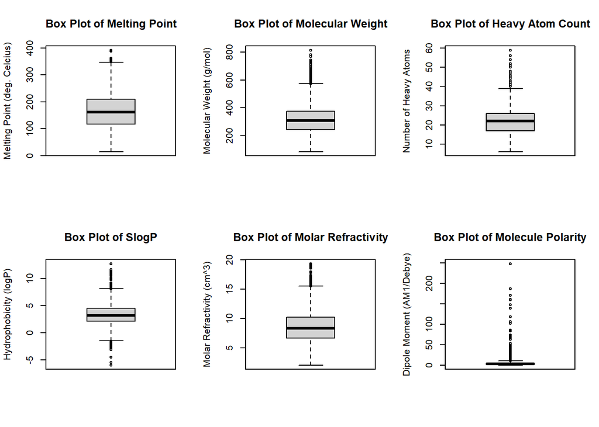

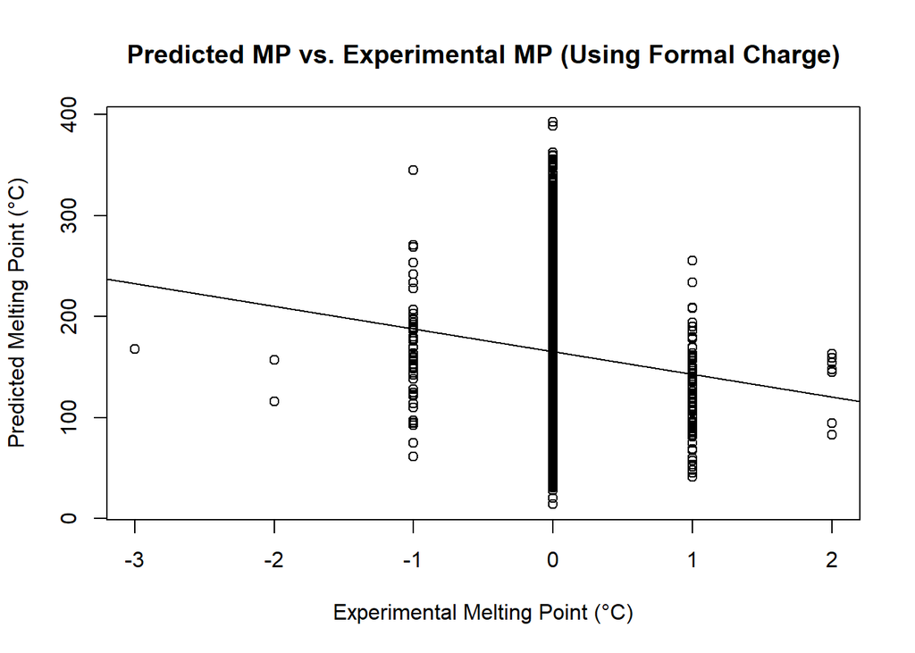

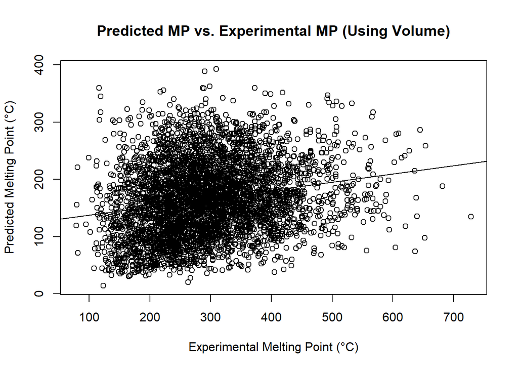

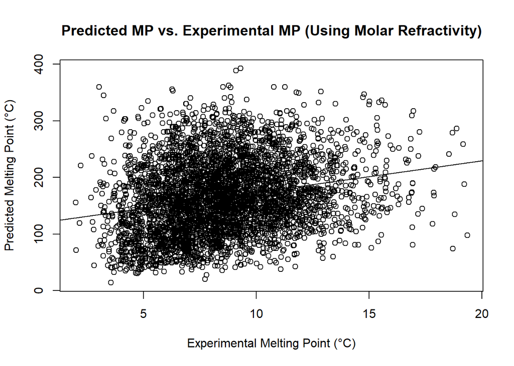

```r
mult_reg <- lm(mp$mp~mp$formal.charge+mp$volume+mp$refractivity)
summary(mult_reg)
```

```
##
## Call:
## lm(formula = mp$mp ~ mp$formal.charge + mp$volume + mp$refractivity)
##
## Residuals:
##      Min       1Q   Median       3Q      Max
## -151.529  -46.495   -5.889   42.009  230.036
##
## Coefficients:
##                   Estimate Std. Error t value Pr(>|t|)
## (Intercept)      123.01167    3.10703  39.591  < 2e-16 ***
## mp$formal.charge -22.78054    4.33599  -5.254 1.56e-07 ***
## mp$volume         -0.71869    0.06285 -11.435  < 2e-16 ***
## mp$refractivity   29.85526    2.14004  13.951  < 2e-16 ***
## ---
## Signif. codes:  0 '***' 0.001 '**' 0.01 '*' 0.05 '.' 0.1 ' ' 1
##
## Residual standard error: 61.22 on 4446 degrees of freedom
## Multiple R-squared:  0.0888, Adjusted R-squared:  0.08818
## F-statistic: 144.4 on 3 and 4446 DF,  p-value: < 2.2e-16
```

## BIC Analysis

Yet another model that can be used to analyze the data is the BIC model. BIC models are used to determine causality between to variables, somewhat similar in purpose to linear regressions. In other words, BIC models measure the degree to which variable y happens as a result of variable x. When calculating BIC, the score between two variables is compared to the variable being CAUSED (y) to determine causality. If the difference between the two is ten or greater, causality is said to be likely. For example, observe the BIC score testing for whether molar refractivity causes melting point.

```r
mp_to_self <- BIC(lm(mp$mp~1)) # 49,674.4
refrac_to_mp <- BIC(lm(mp$mp~mp$refractivity)) # 49,431.56
paste("Difference of ", mp_to_self - refrac_to_mp)
```

```
## [1] "Difference of  242.839579331827"
```